# DATA202/DATA472 Assignment 3

### Due: Friday, 24 May 2024 at 6:00 PM NZST, Worth 10%

- Submit the assignment using the ECS submission system.
- Submit **only** the file `assignment4.Rmd`.
- Make sure the file knits correctly to a .html file. You will need to fix your errors and resubmit if it does not create a .html file.
- **Check your output.** Open the .html file and make sure it contains your answers as you expect to see them.
- You can resubmit as many times as you like up to the assessment deadline.
- Make sure your name and student ID number are at the top of your file, that your `R` code is in executable chunks, and any comments are included as text.
- Also please note the **Student Honour Code**, which you agree to when you submit:

> When submitting my work I confirm:
> - I have completed all steps of the attached assessment on my own,
> - I have not used any unauthorised materials while completing this assessment, and
> - I have not given anyone else access to my assessment.

#### Assignment Questions

**Q1. (7 Marks)**

In the game of blackjack, players are dealt two cards from a standard 52-card playing deck. Cards have different point values with a 1 (*i.e.*, ace) worth either 1 or 11 points (at the choice of the player), cards numbered 2 to 10 worth points equal to the number on the card, and cards that are a face card (*i.e.*, jack, queen, or king, which can be considered as being numbers 11 to 13 with 11 = jack, 12 = queen, and 13 = king) worth 10 points. A blackjack occurs when the two cards dealt to a player sum to 21 points (*i.e.*, one of the cards is an ace/1, and the other card is either a 10, jack, queen, or king).

In casinos, a number of decks (usually six or more) are shuffled together to prevent people from counting cards. In such a situation, the cards that are dealt approximately represent a situation where cards are drawn randomly from a deck **with replacement**. Write code to simulate 10,000 repetitions of two cards being dealt to a player, where cards are drawn **with replacement**. Using the relative frequency of incidence of a blackjack in these 10,000 repetitions of two cards being drawn, provide an estimate for the probability of getting a blackjack when playing at a casino.

```r
set.seed(0)
N = 10000
draw_cards <- function() {
  deck <- c(1,1,1,1, rep(2:10, each = 4), rep(10, 12))
  hand <- sample(deck, 2, replace = TRUE)

  # If the hand is 21, blackjack
  if (sum(hand) == 21) { return(TRUE) }

  # If the hand is 10 + 1, the 1 can function as an 11, so blackjack
  if (sum(hand) == 11 & 1 %in% hand) {
    return(TRUE)
  }

  return(FALSE)
}

num_blackjacks <- sum(replicate(N, draw_cards()))

prob_blackjack <- num_blackjacks / N
prob_blackjack
```

```
## [1] 0.0492
```

**Q2. (13 Marks)**

Consider a barber shop that is open from 10:00 AM to 6:00 PM (*i.e.*, 8 hours) each day. Suppose that the number of customers arriving at the barber shop each hour follows a Poisson distribution with rate $\lambda = 3$ customers per hour. Assume that the barber shop can service up to 4 customers per hour. (Note that we are ignoring the timing of when customers arrive, so we assume that up to 4 customers are serviced every hour, regardless of when they arrive in that hour.) Any customers not serviced in a given hour are added to the number of customers arriving in the next hour (e.g., if 6 customers arrive in a given hour, then 2 of them will need to wait until the next hour to get their hair cut). At the end of the day, any queue of customers waiting to get their hair cut is cleared, so the next day starts with only the customers arriving in the first hour of that day.

1. **[9 marks]** Write a function called `waiting_customers` that simulates one day at the barber shop. The function should have the following arguments:
   - `lambda`: the rate of customers per hour arriving at the barber shop.
   - `customers`: the number of customers that can be serviced each hour.
   - `hours`: the number of hours that the barber shop is open for a given day.

   The function should return a vector that gives the number of customers that are still waiting for a haircut at the end of each hour.

   Show code for your function as well as output from running your function to simulate one day at the barber shop. (For your simulation of one day at the barber shop, make use of the information provided above, where the barber shop is open for 8 hours a day, customers arrive at the barber shop at a rate of 3 customers per hour, and the barber shop can service up to 4 customers each hour.)

```r
set.seed(0)
waiting_customers <- function(lambda, customers, hours) {
  waiting <- numeric(hours)

  for (i in 1:hours) {
    arrivals <- rpois(1, lambda)

    waiting[i] <- max(0, waiting[i] + arrivals - customers)

    if (i < hours) {
      waiting[i+1] <- waiting[i]
    }
  }

  return(waiting)
}

waiting_customers(3, 4, 8)
```

```
## [1] 1 0 0 0 1 0 1 3
```

2. **[4 marks]** Now simulate 10,000 days at the barber shop. Use `ggplot` to produce an appropriate graphical display of the distribution of customers waiting at the end of each hour. Additionally, estimate the mean number of customers waiting at the end of each hour.

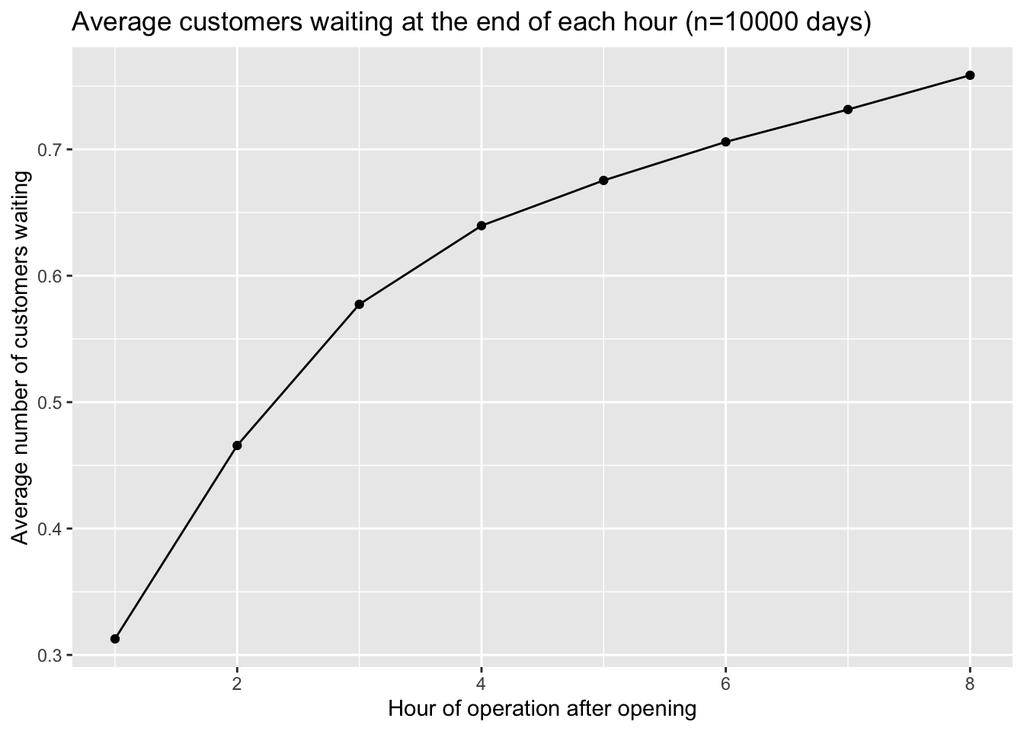

```r
set.seed(0)
library(ggplot2)

replicate_simulation <- function(lambda, customers, hours, num_days) {
  waiting_data <- matrix(0, nrow = num_days, ncol = hours)

  for (i in 1:num_days) {
    waiting_data[i,] <- waiting_customers(lambda, customers, hours)
  }

  return(waiting_data)
}

waiting_data <- replicate_simulation(3, 4, 8, 10000)

ggplot(data.frame(hour = 1:8, mean_wait = apply(waiting_data, 2, mean)), aes(x = hour, y = mean_wait)) +
  geom_line() +
  geom_point() +
  labs(x = "Hour of operation after opening", y = "Average number of customers waiting", title = "Average customers waiting at the end of each hour (n=10000 days)")
```

**Q3. (10 Marks)**

Recall the Monty Hall Problem, but now suppose that there is $10,000 behind one door and goats behind the other two doors. The contestant selects a door and then is presented with two options:

1. End the game and take $3,000.
2. Have Monty Hall select one of the other two doors randomly. If the selected door contains $10,000, the player automatically loses. If the selected door contains a goat, then the player has another two options:
   - stick with their initial choice or
   - change doors.

Of the three possible options (end the game and take $3,000, play on but stick with their initial choice, or play on but change doors), which strategy (or strategies) produce(s) the largest expected value for winnings? Simulate 10,000 plays of the game using each strategy to answer this question.

```r
set.seed(0)
simulate_monty_hall <- function(strategy) {
  doors <- c("$10,000", "Goat", "Goat")

  contestant_choice <- sample(1:3, 1)
  monty_choice <- sample(setdiff(1:3, contestant_choice), 1)

  # If the strategy is to end the game and take $3,000
  if (strategy == "end_game") {
    return(3000)
  }

  if (strategy == "stick") {
    if (doors[contestant_choice] == "$10,000") {
      return(10000)
    }
    return(0)
  }

  remaining <- setdiff(1:3, c(contestant_choice, monty_choice))
  if (doors[remaining] == "$10,000") {
    return(10000)
  }
  return(0)
}

run_simulations <- function(strategy, num_plays) {
  total_winnings <- 0
  for (i in 1:num_plays) {
    total_winnings <- total_winnings + simulate_monty_hall(strategy)
  }
  return(total_winnings / num_plays)
}

N <- 10000

cat("End the game: $", run_simulations("end_game", N), "\n")
```

```
## End the game: $ 3000
```

```r
cat("Stick with initial door choice: $", run_simulations("stick", N), "\n")
```

```
## Stick with initial door choice: $ 3321
```

```r
cat("Change doors: $", run_simulations("change", N), "\n")
```

```
## Change doors: $ 3284
```

**Q4. (10 Marks)**

1. **[8 marks]** Write a function called `er.graph` to simulate networks according to an Erdős–Rényi (or Bernoulli) model. There are several variants of the Erdős–Rényi model, but the simplest version (and the one you should implement for `er.graph`) uses a Bernoulli distribution to randomly generate edges for each possible edge in the network with common probability *p* (*i.e.*, for each pair of nodes, the probability of an edge between the two nodes is *p*). Your function should perform error checking for arguments. (Note: You should not make use of functions from any other packages [such as `network`, `sna`, etc.] in your function.)

   **Description**

   Function to simulate random networks according to an Erdős–Rényi (or Bernoulli) model.

   **Usage**

   ```r
   er.graph(n, tprob = 0.5, mode = "digraph")
   ```

   **Arguments**

   | n | a positive integer specifying the number of nodes in the network. |
   | --- | --- |
   | tprob | the common edge probability *p*. |
   | mode | “digraph” for directed network, “graph” for undirected network. |

   **Details**

   er.graph simulates random networks using an Erdős–Rényi model. For each possible edge in the network, a Bernoulli distribution with common probability *p* (given by tprob) is used to simulate whether the edge exists or not. The function supports both directed networks (by specifying mode = “digraph”. This is the function default) and undirected networks (by specifying mode = “graph”).

   **Value**

   The function returns an $n \times n$ adjacency matrix.

   **Example**

   ```r
   set.seed(0)
   er.graph(15, prob = 0.2, mode = "graph")
   er.graph(10, prob = 0.7)
   ```

```r
er.graph <- function(n, tprob = 0.5, mode = "digraph") {
  result <- matrix(0, nrow = n, ncol = n)

  for (i in 1:n) {
    for (j in 1:n) {
      if (i != j) {
        if (mode == "digraph") {
          if (runif(1) <= tprob) {
            result[i, j] <- 1
          }
        } else if (mode == "graph" && i < j) {
          if (runif(1) <= tprob) {
            result[i, j] <- 1
            result[j, i] <- 1
          }
        }
      }
    }
  }

  return(result)
}
```

2. **[2 marks]** Show output for your code when it is run for the following function specifications:

```r
set.seed(0)
er.graph(6.5)
```

```
##      [,1] [,2] [,3] [,4] [,5] [,6]
## [1,]    0    0    1    1    0    0
## [2,]    1    0    0    0    0    0
## [3,]    1    1    0    1    0    1
## [4,]    0    1    0    0    0    1
## [5,]    0    0    1    0    0    1
## [6,]    1    1    1    1    0    0
```

```r
er.graph(6, tprob = 1.1)
```

```
##      [,1] [,2] [,3] [,4] [,5] [,6]
## [1,]    0    1    1    1    1    1
## [2,]    1    0    1    1    1    1
## [3,]    1    1    0    1    1    1
## [4,]    1    1    1    0    1    1
## [5,]    1    1    1    1    0    1
## [6,]    1    1    1    1    1    0
```

```r
er.graph(6, tprob = 1, mode = 'directed')
```

```
##      [,1] [,2] [,3] [,4] [,5] [,6]
## [1,]    0    0    0    0    0    0
## [2,]    0    0    0    0    0    0
## [3,]    0    0    0    0    0    0
## [4,]    0    0    0    0    0    0
## [5,]    0    0    0    0    0    0
## [6,]    0    0    0    0    0    0
```

```r
er.graph(8, tprob = 0.2)
```

```
##      [,1] [,2] [,3] [,4] [,5] [,6] [,7] [,8]
## [1,]    0    0    0    0    0    0    0    0
## [2,]    0    0    0    1    0    0    0    0
## [3,]    0    0    0    0    0    0    0    0
## [4,]    0    0    0    0    0    0    0    0
## [5,]    1    0    1    0    0    1    0    0
## [6,]    0    0    0    0    0    0    0    0
## [7,]    0    0    0    0    0    1    0    0
## [8,]    0    0    0    0    0    0    1    0
```

```r
er.graph(8, tprob = 0.5, mode = 'graph')
```

```
##      [,1] [,2] [,3] [,4] [,5] [,6] [,7] [,8]
## [1,]    0    1    0    1    1    0    0    1
## [2,]    1    0    1    1    0    1    0    1
## [3,]    0    1    0    1    0    0    1    1
## [4,]    1    1    1    0    0    0    0    0
## [5,]    1    0    0    0    0    0    0    0
## [6,]    0    1    0    0    0    0    0    0
## [7,]    0    0    1    0    0    0    0    1
## [8,]    1    1    1    0    0    0    1    0
```

**(Assignment total: 40 Marks)**